# FisherExample + Galton

David Špetla

2022-10-16

## Fisheruv test

- cteni: [Wiki](https://en.wikipedia.org/wiki/Lady_tasting_tea)

```r
TeaTasting <-
matrix(c(3, 1, 1, 3),
       nrow = 2,
       dimnames = list(Guess = c("Milk", "Tea"),
                       Truth = c("Milk", "Tea")))
fisher.test(TeaTasting, alternative = "greater")
```

```
##
##  Fisher's Exact Test for Count Data
##
## data:  TeaTasting
## p-value = 0.2429
## alternative hypothesis: true odds ratio is greater than 1
## 95 percent confidence interval:
##  0.3135693       Inf
## sample estimates:
## odds ratio
##   6.408309
```

## Regresní analýza Galtonových dat

Protože jsem se během léta prokousal knihou *Statistics for Linguists: An Introduction Using R* (2020) od Boda Wintera, přemýšlel jsem na našem pátečním semináři, jak by se asi dala upravit a analyzovat Galtonova data výšek rodičů a dětí pomocí lineární regrese. Svůj pokus představuji níže.

K analýze budeme používat balíček `tidyverse` a `broom`.

```r
library(tidyverse)
library(broom)
```

Nejprve si načteme data a podíváme se, jak jsou strukturována. Data byla stažena ve formátu .csv z webové adresy http://www.randomservices.org/random/data/Galton.html.

```r
galton <- read_csv("Galton.csv")
galton
```

```
## # A tibble: 898 × 6
##    Family Father Mother Gender Height  Kids
##     <dbl>  <dbl>  <dbl> <chr>   <dbl> <dbl>
##  1      1   78.5   67   M        73.2     4
##  2      1   78.5   67   F        69.2     4
##  3      1   78.5   67   F        69       4
##  4      1   78.5   67   F        69       4
##  5      2   75.5   66.5 M        73.5     4
##  6      2   75.5   66.5 M        72.5     4
##  7      2   75.5   66.5 F        65.5     4
##  8      2   75.5   66.5 F        65.5     4
##  9      3   75     64   M        71       2
## 10      3   75     64   F        68       2
## # … with 888 more rows
```

Všimněme si, že míry jsou uvedeny v palcích. Aby bylo lze data snáze interpretovat, převeďme si všechny míry do centimetrů.

```r
galton <- galton %>% mutate(Father = Father * 2.54, Mother = Mother * 2.54, Height = Height * 2.54)
galton
```

```
## # A tibble: 898 × 6
##    Family Father Mother Gender Height  Kids
##     <dbl>  <dbl>  <dbl> <chr>   <dbl> <dbl>
##  1      1   199.   170. M        186.     4
##  2      1   199.   170. F        176.     4
##  3      1   199.   170. F        175.     4
##  4      1   199.   170. F        175.     4
##  5      2   192.   169. M        187.     4
##  6      2   192.   169. M        184.     4
##  7      2   192.   169. F        166.     4
##  8      2   192.   169. F        166.     4
##  9      3   190.   163. M        180.     2
## 10      3   190.   163. F        173.     2
## # … with 888 more rows
```

### Lineární modelování

#### Výška rodičů

Vytvoříme si lineární modely pro otce a matku zvlášť a vypočítané hodnoty zobrazíme pomocí funkce `tidy` z balíčku `broom`. Odhad zaokrouhlíme na tři desetinná místa.

```r
# Model pro otce:
mdl_father <- lm(galton, formula = Height ~ Father)
tidy(mdl_father) %>% mutate(estimate = round(estimate, 3))
```

```
## # A tibble: 2 × 5
##   term        estimate std.error statistic  p.value
##   <chr>          <dbl>     <dbl>     <dbl>    <dbl>
## 1 (Intercept)   99.3      8.20       12.1  2.06e-31
## 2 Father         0.399    0.0466      8.57 4.35e-17
```

```r
# Model pro matku:
mdl_mother <- lm(galton, formula = Height ~ Mother)
tidy(mdl_mother) %>% mutate(estimate = round(estimate, 3))
```

```
## # A tibble: 2 × 5
##   term        estimate std.error statistic  p.value
##   <chr>          <dbl>     <dbl>     <dbl>    <dbl>
## 1 (Intercept)  119.       8.28       14.3  4.47e-42
## 2 Mother         0.313    0.0508      6.16 1.08e- 9
```

Jak napovídají směrnice přímek (a. *slopes*) v obou modelech, přímka modelu závislosti výšky dítěte na otcově výšce je strmější (`0.399`) než v případě závislosti na výšce matčině (`0.313`). Matčina přímka má navíc průsečík s osou *y* (a. *intercept*) výš (`99.340` oproti `118.594`). Modely si můžeme zobrazit v grafech.

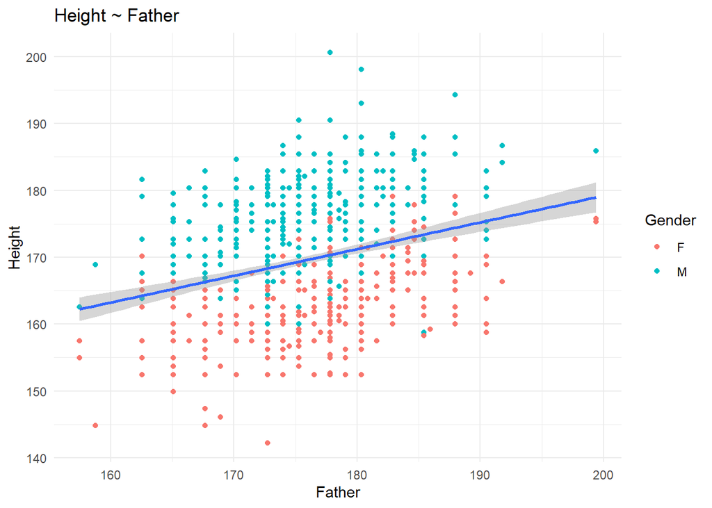

```r
# Výška v závislosti na otci:
galton %>% ggplot(aes(x = Father, y = Height)) +
  geom_point(aes(color = Gender)) +
  scale_y_continuous(breaks = seq(0, 210, by = 10)) +
  geom_smooth(method = "lm") + ggtitle("Height ~ Father") +
  theme_minimal()
```

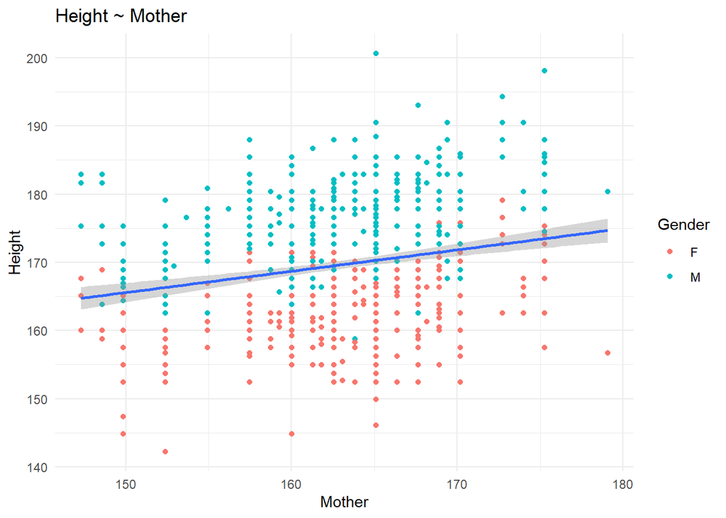

```r
# Výška v závislosti na matce:
galton %>% ggplot(aes(x = Mother, y = Height)) +
  geom_point(aes(color = Gender)) +
  scale_y_continuous(breaks = seq(0, 210, by = 10)) +
  geom_smooth(method = "lm") + ggtitle("Height ~ Mother") +
  theme_minimal()
```

#### Pohlaví

Můžeme si také vytvořit model pro pohlaví dítěte.

```r
mdl_gender <- lm(galton, formula = Height ~ Gender)
tidy(mdl_gender)
```

```
## # A tibble: 2 × 5
##   term        estimate std.error statistic   p.value
##   <chr>          <dbl>     <dbl>     <dbl>     <dbl>
## 1 (Intercept)    163.      0.306     532.  0
## 2 GenderM         13.0     0.426      30.5 5.18e-141
```

Protože se jedná o kategoriální proměnnou (v *treatment coding*), výsledkem je rozdíl průměrů obou kategorií.

```r
mean_by_gender <- galton %>% group_by(Gender) %>% summarize(mean = mean(Height))
abs(mean_by_gender$mean[1] - mean_by_gender$mean[2])
```

```
## [1] 13.00139
```

Synové jsou tedy v průměru o 13 cm vyšší než dcery, což dokládá krabicový graf.

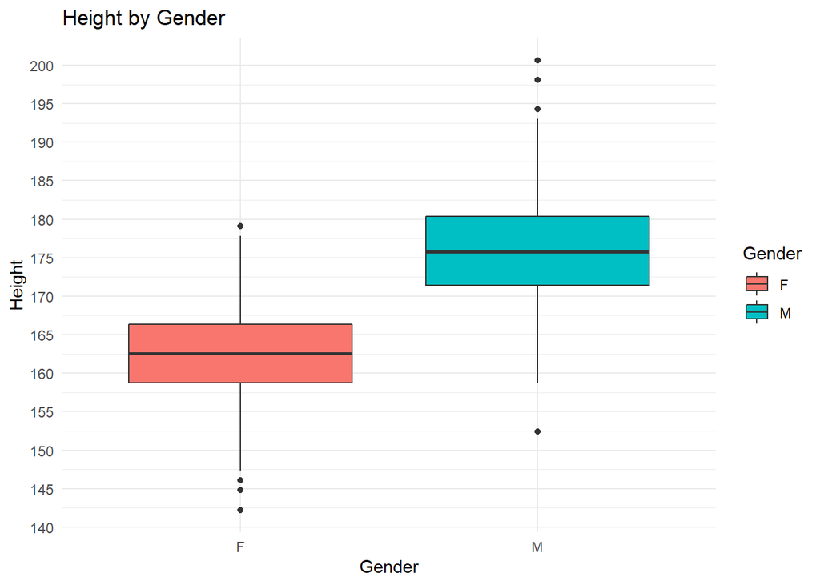

```r
galton %>% ggplot() + geom_boxplot(aes(x = Gender, y = Height, fill = Gender)) +
  ggtitle("Height by Gender") +
  scale_y_continuous(breaks = seq(0, 210, by = 5)) +
  theme_minimal()
```

#### Vícenásobná regrese

Výše uvedené nezávislé proměnné můžeme zkombinovat do jediného modelu.

```r
mdl_pargen <- lm(galton, formula = Height ~ Father + Mother + Gender)
tidy(mdl_pargen)
```

```
## # A tibble: 4 × 5
##   term        estimate std.error statistic   p.value
##   <chr>          <dbl>     <dbl>     <dbl>     <dbl>
## 1 (Intercept)   39.0      6.98        5.59 3.08e-  8
## 2 Father         0.406    0.0292     13.9  6.53e- 40
## 3 Mother         0.321    0.0313     10.3  1.70e- 23
## 4 GenderM       13.3      0.366      36.3  5.79e-178
```

Model mnohonásobné regrese předpovídá podobné hodnoty, jako jednotlivé modely pro každou proměnnou zvlášť. Tímto analýzu končím, protože se dostávám na čím dál nejistější půdu.

### Závěr

Výška otce se zdá mít na výšku dítěte větší dopad než výška matky. Samozřejmě by bylo záhodno zkoumat syny a dcery zvlášť, protože synové jsou v průměru vyšší než dcery.